# VGI papers analysis for creating final figures included in submitted paper

Carlos Granell

August 2015

## Synopsis

This paper investigates the research that has been carried out on volunteered geographic information using the method of a systematic mapping study. It describes the development of a classification schema that captures three levels of main focus, sub-focus and intended use, and analyzes the relationships with the employed data sources and analysis methods. It purposefully limits the scope to the pioneering field of crisis management and disaster response, but the described approach - the systematic mapping study - and the developed classification schema are easily adaptable to different application domains or future developments.

The results show that a hypothesized consolidation of research, characterized through the building of canonical bodies of knowledge and advanced application cases with refined methodology, has not yet happened. The majority of the studies investigate the challenges and potential solutions of data handling, with fewer studies focusing on socio-technological issues or advanced applications. This trend is currently showing no sign of change, highlighting that VGI research is still very much technologydriven as opposed to theory- or application-driven. From the results of the systematic mapping study, the authors formulate and discuss several research objectives for future work, which could lead to a stronger, more theory-driven treatment of the topic VGI in GIScience.

## Loading data

```r
setwd("C:/Users/cgranell/Data/MyCode/paper-vgi-science/")
url <- "https://github.com/cgranell/paper-vgi-science/raw/master/data/ceus/cleandata.rda"
dataFile <- "cleandata.rda"
pathToDataFile <- paste("./data/ceus/", dataFile, sep="")

if (!file.exists(pathToDataFile)) {
    file <- download.file(url, destfile=pathToDataFile)
}

load(pathToDataFile)
```

## Preprocessing scripts

```r
getUniqueVenues <- function() {
    papers <- unique(data$p.id)
    numPapers = length(papers)

    venues <- data.frame(
        p.id=character(numPapers),
        p.venue=character(numPapers),
        p.venuetype=character(numPapers),
        stringsAsFactors=FALSE)


    for (i in 1:numPapers) {
        firstVenue <- sapply(data[data$p.id==papers[i], c("p.venue", "p.venuetype")], function(d) {d[1]})
        # Add a new row (paper id + first ocurrence of venue) to the data.frame
        venues [i, ] <- c(papers[i],
                          as.character(firstVenue[c("p.venue")]),
                          as.character(firstVenue[c("p.venuetype")]))
    }
    return (venues)
}
```

```r
getUniqueSources <- function() {
    papers <- unique(data$p.id)
    numPapers = length(papers)

    sources <- data.frame(
        p.id=character(numPapers),
        f.cat0=character(numPapers),
        f.cat1=character(numPapers),
        d.source=character(numPapers),
        d.official=character(numPapers),
        stringsAsFactors=FALSE)


    for (i in 1:numPapers) {
        firstSource <- sapply(data[data$p.id==papers[i], c("f.cat0", "f.cat1", "f.uc0", "d.source", "d.official")], function(d) {d[1]})
        # Add a new row (paper id + first ocurrence of source) to the data.frame
        sources [i, ] <- c(papers[i],
                           as.character(firstSource[c("f.cat0")]),
                           as.character(firstSource[c("f.cat1")]),
                           as.character(firstSource[c("d.source")]),
                           as.character(firstSource[c("d.official")]))
    }
    return (sources)
}
```

```r
percent <- function(x, digits = 2, format = "f", ...) {
    paste0(formatC(100 * x, format = format, digits = digits, ...), "%")
}
```

## Results: Final figures

R scripts below describe how the data were processed for creating figures included in the submitted paper.

### Distribution of publication venues

What are the publication venues VGI research & data science have been published in?

```r
# get the list of unique venues
subsetVenues <- getUniqueVenues()

# Run the function table() on the value of "p.venue" for each group (p.venue, p.venuetype)
subsetVenues0 <- ddply(subsetVenues, c("p.venue", "p.venuetype"), summarise,
           countVenue  = as.integer(table(p.venue)))

# Journal and conference rates. Note that total is 57 because one paper is a technical report
sumJournals <- sum(subsetVenues0[subsetVenues0$p.venuetype=="journal", c("countVenue")])
sumConferences <- sum(subsetVenues0[subsetVenues0$p.venuetype=="conference", c("countVenue")])
rateJournals <- (sumJournals / (sumJournals + sumConferences))
rateConferences <- (sumConferences / (sumJournals + sumConferences))

# Legend labels including  percent
legend.txt = c(paste0("Conference: ", percent(rateConferences)), paste0("Journal: ", percent(rateJournals)))
legend.txt
```

```
## [1] "Conference: 45.61%" "Journal: 54.39%"
```

```r
### RQ2: Focus and intended uses of papers
```

Fig 5a shows the distribution of papers along the main categories

```r
subsetCat <- data[,c("p.id", "f.cat0","f.cat1", "f.cat2", "p.year")]
# Run the function length() on the unique values of "p.id" for each group (f.cat0)
subsetCat0 <- ddply(subsetCat, c("f.cat0"), summarise,
                    countCat0  = length(unique(p.id)))
```

Fig5b shows the distribution of use cases along the main categories

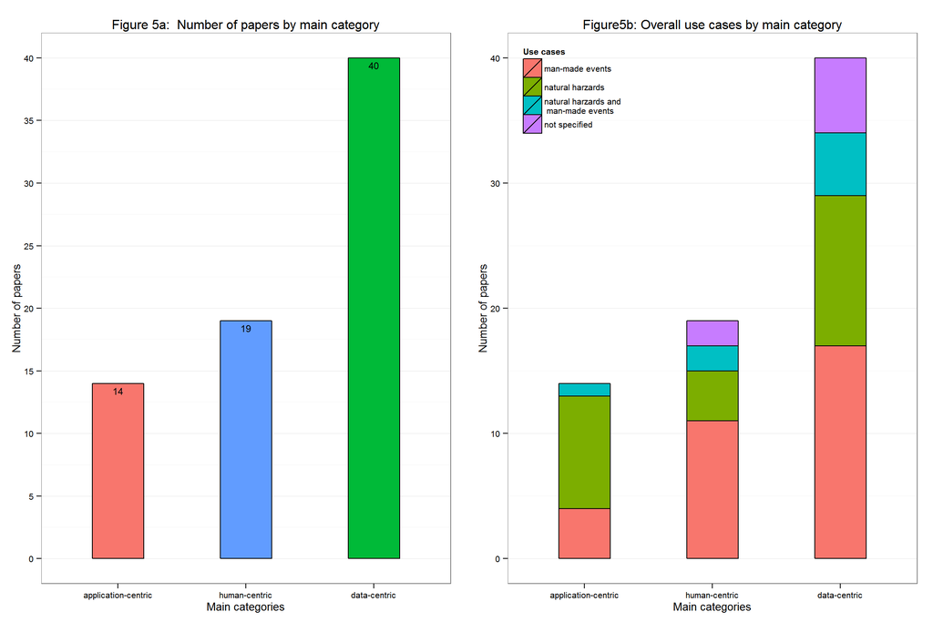

```r
subsetUseCases <- data[,c("p.id", "f.cat0","f.cat1", "f.cat2", "f.uc0", "f.uc1", "p.year")]

# Run the function length() on the unique values of "p.id" for each group (f.cat0, f.uc0)
subsetUseCases0 <- ddply(subsetUseCases, c("f.cat0", "f.uc0"), summarise,
                         countCat0  = length(unique(p.id)))

levels(subsetUseCases0$f.uc0)[levels(subsetUseCases0$f.uc0)=="natural harzards and man-made events"] <- "natural harzards and\n man-made events"

# Turn NA as a factor level
subsetUseCases0$f.uc0 <- addNA(subsetUseCases0$f.uc0)
# Rename level of a factor by index: change fourh item, NA, to "not specified".
levels(subsetUseCases0$f.uc0)[4] <- "not specified"
```

Fig 6 shows the distribution of sub-categories/focuses within each category. (Note 19 Aug 2015: This figure will not be part of the paper. Instead, we have updated the next three figures to add the total number of papers per subcategory in parenthesis in the legend. For the time being, this figure is still relevant for internal use in case more papers are added to the review)

```r
# Run the function length() on the unique value of "p.id" for each group (f.cat0, f.cat1)
# to sum the ocurrences  of f.cat1 within each group
subsetCat1 <- ddply(subsetCat, c("f.cat0", "f.cat1"), summarise,
                        countCat1 = length(f.cat1))

# Get the sub-category (f.cat1), sorted first by category (f.cat0), then by count
cat1order <- subsetCat1$f.cat1[order(subsetCat1$f.cat0, subsetCat1$countCat1)]
# Turn f.cat1 into a factor, with levels in the order of cat1order
subsetCat1$f.cat1 <- factor(subsetCat1$f.cat1, levels=cat1order)
```

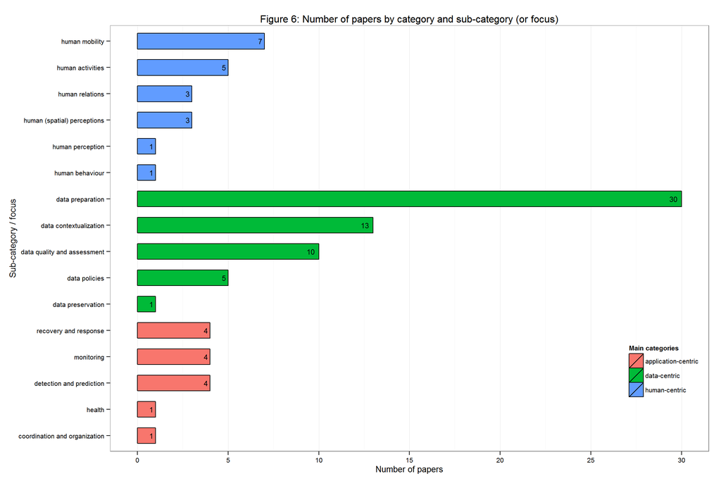

Fig 7 shows the most frequently intended uses within the data-centric category

```r
# Run the function length() on the value of "f.cat2" for each group (f.cat0, f.cat1, f.cat2)
# to sum the ocurrences  of f.cat2 within each group
subsetCat2 <- ddply(subsetCat, c("f.cat0", "f.cat1", "f.cat2"), summarise,
                    countCat2 = length(f.cat2))

dataCentric <- subset(subsetCat2,f.cat0=="data-centric")

# Get the intended uses (f.cat2), sorted first by cat1 (focus), then by count
cat2order <- dataCentric$f.cat2[order(dataCentric$f.cat1, dataCentric$countCat2)]
# Turn f.cat2 into a factor, with levels in the order of cat2order
dataCentric$f.cat2 <- factor(dataCentric$f.cat2, levels=cat2order)

# A trick to change legend title is to rename the column in the dataframe
names(dataCentric)[names(dataCentric)=="f.cat1"]  <- "Focus"

# Change legend labels to add the total number of papers that belong to each subcategory (f.cat1).
dataCentric.limits <- c("data preservation",
                        "data preparation",
                        "data policies",
                        "data contextualization",
                        "data quality and assessment")

dataCentric.legend <- c("data preservation (1)",
                        "data preparation (30)",
                        "data policies (5)",
                        "data contextualization (13)",
                        "data quality and assessment (10)")
```

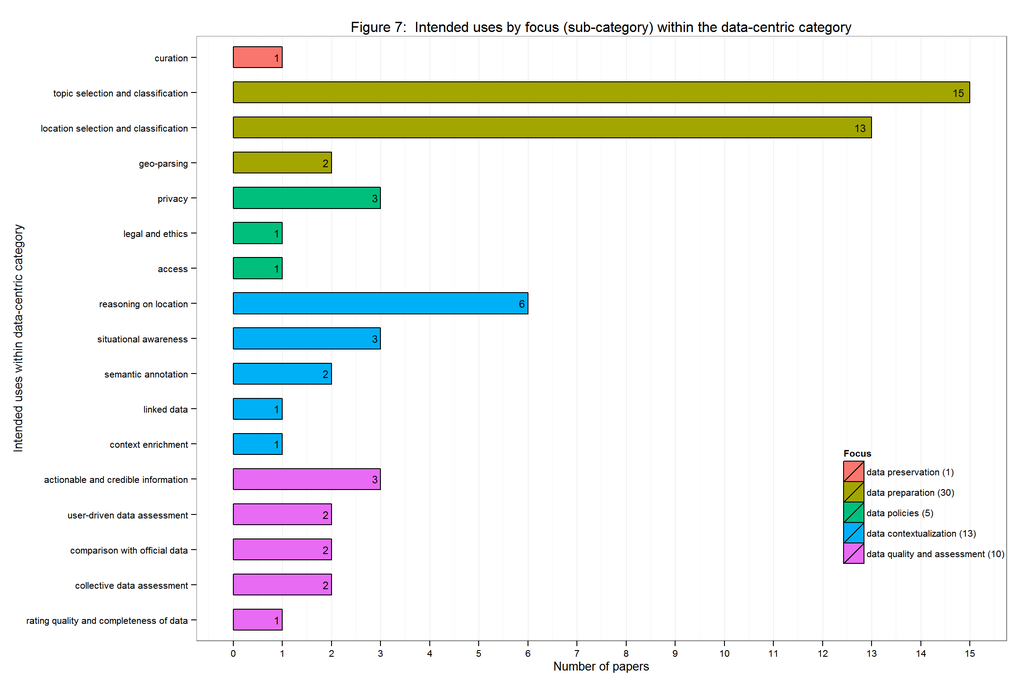

Fig 8 shows the most frequently intended uses within the human-centric category

```r
humanCentric <- subset(subsetCat2,f.cat0=="human-centric")
# Get the intended uses (f.cat2), sorted first by cat1 (focus), then by count
cat2order <- humanCentric$f.cat2[order(humanCentric$f.cat1, humanCentric$countCat2)]
# Turn f.cat2 into a factor, with levels in the order of cat2order
humanCentric$f.cat2 <- factor(humanCentric$f.cat2, levels=cat2order)

# A trick to change legend title is to rename the column in the dataframe
names(humanCentric)[names(humanCentric)=="f.cat1"]  <- "Focus"

# Change legend labels to add the total number of papers that belong to f.cat1.
humanCentric.limits <- c("human relations",
                         "human perception",
                         "human mobility",
                         "human behaviour",
                         "human activities",
                         "human (spatial) perceptions")

humanCentric.legend <- c("human relations (3)",
                         "human perception (1)",
                         "human mobility (7)",
                         "human behaviour (1)",
                         "human activities (5)",
                         "human (spatial) perceptions (3)")
```

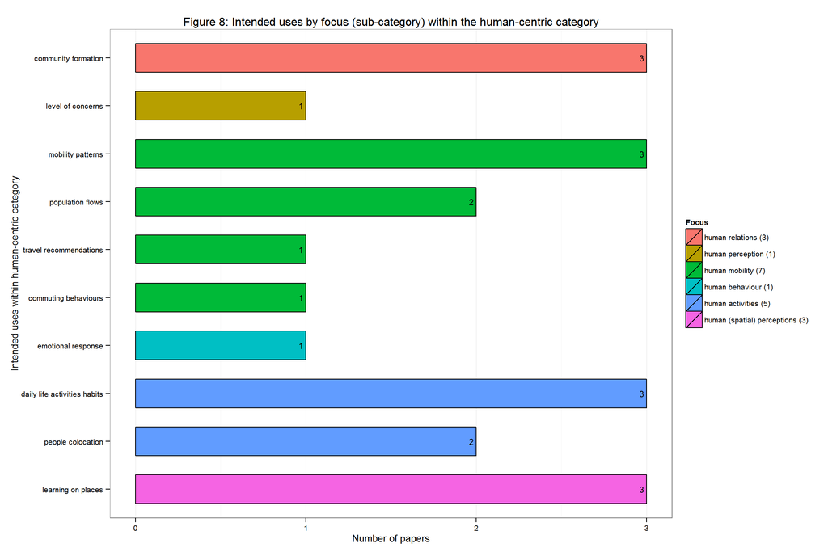

Fig 9 shows the most frequently intended uses within the application-centric category

```r
applicationCentric <- subset(subsetCat2,f.cat0=="application-centric")
# Get the intended uses (f.cat2), sorted first by cat1 (focus), then by count
cat2order <- applicationCentric$f.cat2[order(applicationCentric$f.cat1, applicationCentric$countCat2)]
# Turn f.cat2 into a factor, with levels in the order of cat2order
applicationCentric$f.cat2 <- factor(applicationCentric$f.cat2, levels=cat2order)

# A trick to change legend title is to rename the column in the dataframe
names(applicationCentric)[names(applicationCentric)=="f.cat1"]  <- "Focus"

# Change legend labels to add the total number of papers that belong to f.cat1.
appCentric.limits <- c("recovery and response",
                       "monitoring",
                       "health",
                       "detection and prediction",
                       "coordination and organization")

appCentric.legend <- c("recovery and response (4)",
                       "monitoring (4)",
                       "health (1)",
                       "detection and prediction (4)",
                       "coordination and organization (1)")
```

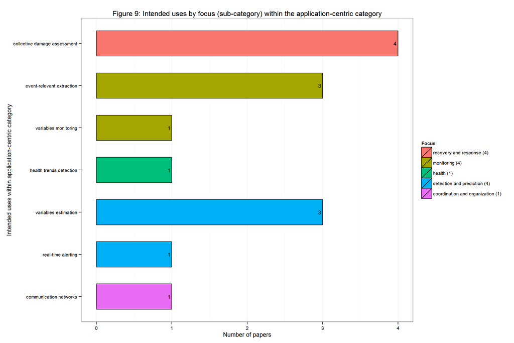

### RQ3: Data Sources

Fig 10 shows the most frequently VGI sources

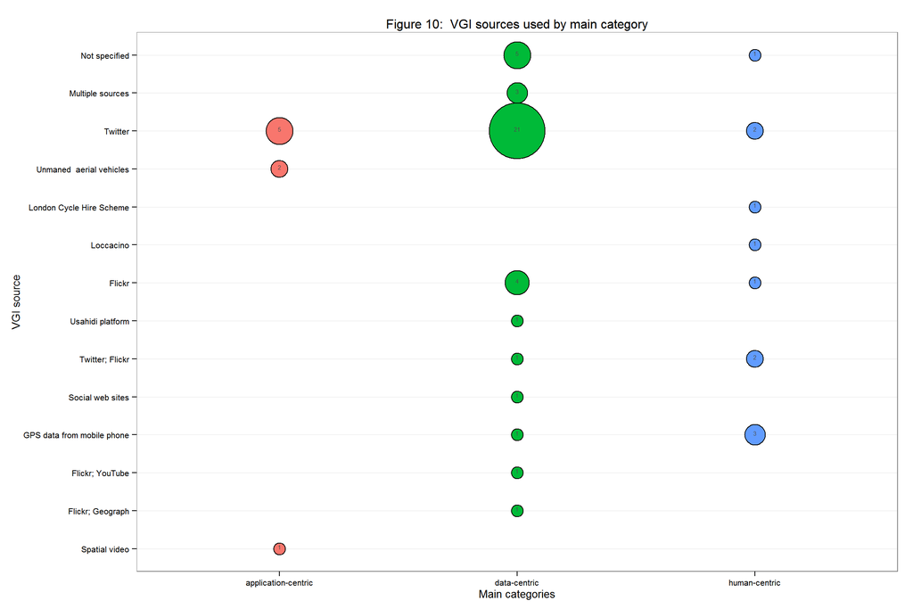

```r
subsetSources <- getUniqueSources()

# Run the function table() on the value of "d.source" for each group (d.source, d.official)
subsetSources0 <- ddply(subsetSources, c("f.cat0", "d.source"), summarise,
                        countSource  = length(d.source))

# Get the sources  (d.source), sorted by count
sourceorder <- subsetSources0$d.source[order(subsetSources0$countSource)]

# Turn d.source into a factor, with levels in the order of sourceorder
subsetSources0$d.source <- factor(subsetSources0$d.source, levels=sourceorder)

# Turn NA as a factor level
subsetSources0$d.source <- addNA(subsetSources0$d.source)
# Rename level of a factor by index: change fourh item, NA, to "Not specified".
levels(subsetSources0$d.source)[19] <- "Not specified"
```

## Distribution of intended uses over time

Fig 11 shows the distribution of intended uses over time by main category

```r
# Run the function length() on the value of "f.cat2" for each group (f.cat0, f.cat1, f.cat2, p.year)
# to sum the ocurrences  of f.cat2 within each group
subsetCat3 <- ddply(subsetCat, c("f.cat0", "f.cat1", "f.cat2", "p.year"), summarise,
                    countCat3 = length(f.cat2))

# Get the intended uses (f.cat2), sorted first by cat1 (focus), then by count
cat2order <- subsetCat3$f.cat2[order(subsetCat3$f.cat1, subsetCat3$countCat3)]
# Turn f.cat2 into a factor, with levels in the order of cat2order
subsetCat3$f.cat2 <- factor(subsetCat3$f.cat2, levels=cat2order)
```

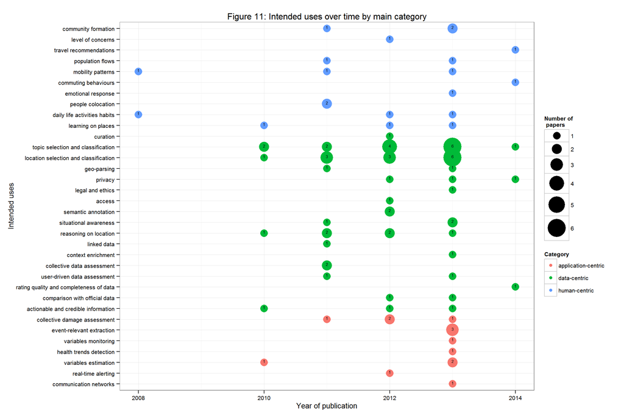